# Machine Learning

## Peer-graded Assignment: Prediction Assignment Writeup

> Background

Using devices such as Jawbone Up, Nike FuelBand, and Fitbit it is now possible to collect a large amount of data about personal activity relatively inexpensively. These type of devices are part of the quantified self movement - a group of enthusiasts who take measurements about themselves regularly to improve their health, to find patterns in their behavior, or because they are tech geeks. One thing that people regularly do is quantify how much of a particular activity they do, but they rarely quantify how well they do it. In this project, your goal will be to use data from accelerometers on the belt, forearm, arm, and dumbell of 6 participants. They were asked to perform barbell lifts correctly and incorrectly in 5 different ways. More information is available from the website here:[Hyperlink](http://web.archive.org/web/20161224072740/http:/groupware.les.inf.puc-rio.br/har) (see the section on the Weight Lifting Exercise Dataset).

> Data

The training data for this project are available here: [Hyperlink](https://d396qusza40orc.cloudfront.net/predmachlearn/pml-training.csv)

The test data are available here: [Hyperlink](https://d396qusza40orc.cloudfront.net/predmachlearn/pml-testing.csv)

**The data resourse: [Hyperlink](http://web.archive.org/web/20161224072740/http:/groupware.les.inf.puc-rio.br/har.)**

> Goal

The goal of this project is to predict the “classe” variable in the data.

> Load the data and library

```r
library(caret)
```

```r
library(rpart)
library(rpart.plot)
library(randomForest)
library(data.table)
```

```r
# get the data and set it as data table

urlTrain <- "http://d396qusza40orc.cloudfront.net/predmachlearn/pml-training.csv"
urlTest  <- "http://d396qusza40orc.cloudfront.net/predmachlearn/pml-testing.csv"

dfTraining <- read.csv(url(urlTrain),na.strings=c("NA","#DIV/0!",""))
dfTesting  <- read.csv(url(urlTest),na.strings=c("NA","#DIV/0!",""))

setDT(dfTraining)
setDT(dfTesting)
```

> Data Cleaning

```r
str(dfTraining)
```

```
## Classes 'data.table' and 'data.frame':   19622 obs. of  160 variables:
##  $ X                       : int  1 2 3 4 5 6 7 8 9 10 ...
##  $ user_name               : Factor w/ 6 levels "adelmo","carlitos",..: 2 2 2 2 2 2 2 2 2 2 ...
##  $ raw_timestamp_part_1    : int  1323084231 1323084231 1323084231 1323084232 1323084232 1323084232 1323084232 1323084232 1323084232 1323084232 ...
##  $ raw_timestamp_part_2    : int  788290 808298 820366 120339 196328 304277 368296 440390 484323 484434 ...
##  $ cvtd_timestamp          : Factor w/ 20 levels "02/12/2011 13:32",..: 9 9 9 9 9 9 9 9 9 9 ...
##  $ new_window              : Factor w/ 2 levels "no","yes": 1 1 1 1 1 1 1 1 1 1 ...
##  $ num_window              : int  11 11 11 12 12 12 12 12 12 12 ...
##  $ roll_belt               : num  1.41 1.41 1.42 1.48 1.48 1.45 1.42 1.42 1.43 1.45 ...
##  $ pitch_belt              : num  8.07 8.07 8.07 8.05 8.07 8.06 8.09 8.13 8.16 8.17 ...
##  $ yaw_belt                : num  -94.4 -94.4 -94.4 -94.4 -94.4 -94.4 -94.4 -94.4 -94.4 -94.4 ...
##  $ total_accel_belt        : int  3 3 3 3 3 3 3 3 3 3 ...
##  $ kurtosis_roll_belt      : num  NA NA NA NA NA NA NA NA NA NA ...
##  $ kurtosis_picth_belt     : num  NA NA NA NA NA NA NA NA NA NA ...
##  $ kurtosis_yaw_belt       : logi  NA NA NA NA NA NA ...
```

[output cut: 87 more lines]

So many NA data

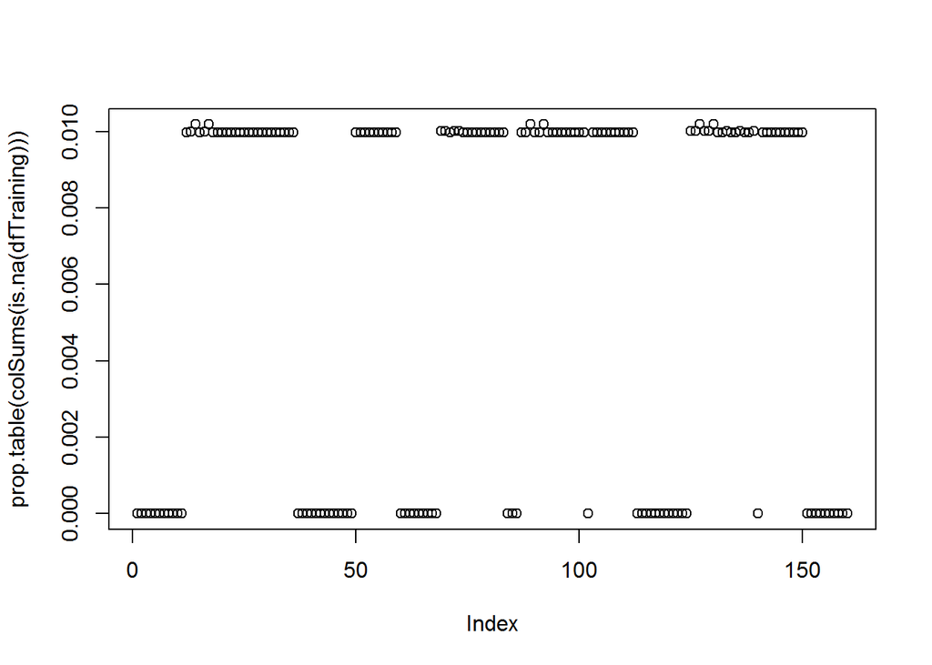

```r
# plot the proposion of NA in every columns. using prob.table
plot(prop.table(colSums(is.na(dfTraining))))
```

Since the NA value is none or all, we can just discard the columns which contain NA data.

```r
# find out the columns which contain NA and remove them

selectedColumns <-dfTraining[,colSums(is.na(dfTraining)) == 0]
selectedTraning <-dfTraining[,..selectedColumns]
selectedTesting <-dfTesting[,..selectedColumns]
dim(dfTraining)
```

```
## [1] 19622   160
```

```r
dim(selectedTraning)
```

```
## [1] 19622    60
```

Removing columns with near zero variance

```r
# using nearzerovar function to find out the variable which is useless
zeroVar<-selectedTraning[,nearZeroVar(selectedTraning)]
myTrain <-selectedTraning[,(zeroVar):=NULL]
myTest <- selectedTesting[,(zeroVar):=NULL]
dim(myTrain)
```

```
## [1] 19622    59
```

```r
dim(myTest)
```

```
## [1] 20 59
```

Since first columns is serial numbers, revoming it avoids wrong prediction in predition model. And also time series data “X”,“user_name”,“raw_timestamp_part_1”,“raw_timestamp_part_2”,“cvtd_timestamp” are being removed

```r
myTrain=myTrain[,-c(1:5)]
```

> Seperate the training data and test data

```r
set.seed(1)
# set up 60% data as training data by sample fuction
 t <-sample(19622,19622*0.6)

iTrain <- myTrain[t,]
iTest <- myTrain[-t,]
```

> Fit the data with ML model: Decision Tress

Create the model and plot

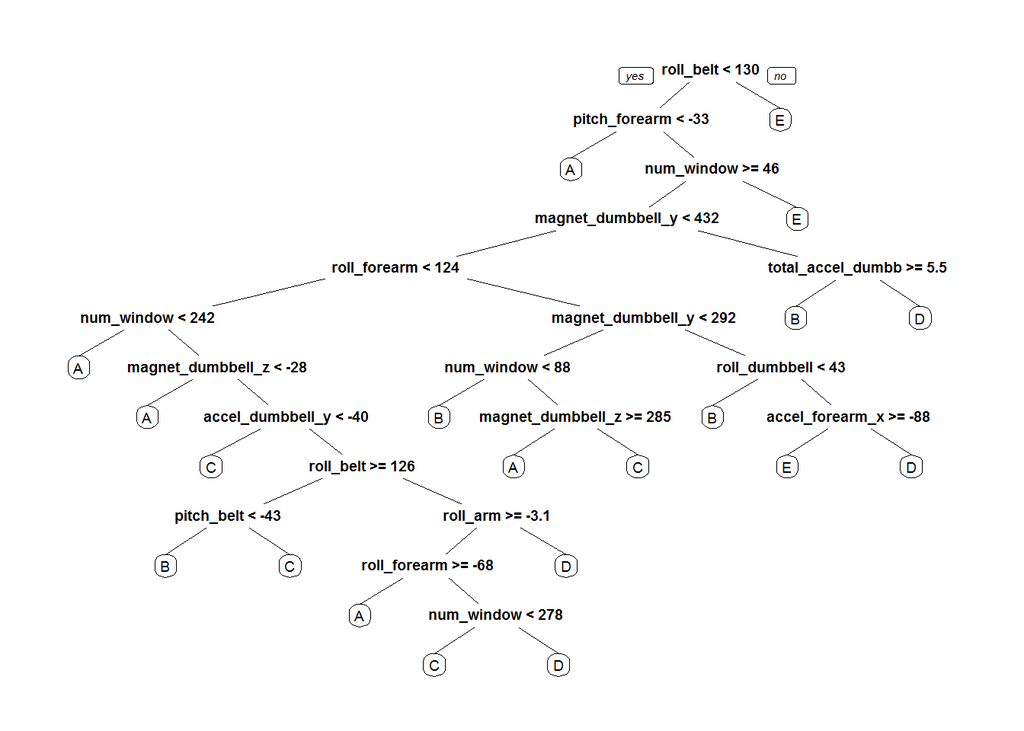

```r
dTree <- rpart(classe ~ ., data=iTrain, method="class")

prp(dTree, cex = .6)
```

Predicting:

```r
predDtree <- predict(dTree, iTest, type = "class")
confusionMatrix(predDtree, iTest$classe)
```

```
## Confusion Matrix and Statistics
##
##           Reference
## Prediction    A    B    C    D    E
##          A 2060  358   36  109   57
##          B   63  769   56   49  104
##          C   13  148 1158  176   84
##          D   75  141  114  787  160
##          E   22   77   92  138 1003
##
## Overall Statistics
##
##                Accuracy : 0.736
##                  95% CI : (0.7261, 0.7457)
##     No Information Rate : 0.2845
##     P-Value [Acc > NIR] : < 2.2e-16
##
##                   Kappa : 0.6641
##  Mcnemar's Test P-Value : < 2.2e-16
##
## Statistics by Class:
##
##                      Class: A Class: B Class: C Class: D Class: E
## Sensitivity            0.9225  0.51507   0.7953   0.6251   0.7124
## Specificity            0.9003  0.95721   0.9341   0.9256   0.9489
## Pos Pred Value         0.7863  0.73871   0.7334   0.6163   0.7530
## Neg Pred Value         0.9669  0.89365   0.9525   0.9282   0.9379
## Prevalence             0.2845  0.19022   0.1855   0.1604   0.1794
## Detection Rate         0.2625  0.09797   0.1475   0.1003   0.1278
## Detection Prevalence   0.3338  0.13263   0.2012   0.1627   0.1697
## Balanced Accuracy      0.9114  0.73614   0.8647   0.7754   0.8306
```

Create a model of Random Forest

```r
RTree <- randomForest(classe ~. , data=iTrain)
summary(RTree)
```

```
##                 Length Class  Mode
## call                3  -none- call
## type                1  -none- character
## predicted       11773  factor numeric
## err.rate         3000  -none- numeric
## confusion          30  -none- numeric
## votes           58865  matrix numeric
## oob.times       11773  -none- numeric
## classes             5  -none- character
## importance         53  -none- numeric
## importanceSD        0  -none- NULL
## localImportance     0  -none- NULL
## proximity           0  -none- NULL
## ntree               1  -none- numeric
## mtry                1  -none- numeric
## forest             14  -none- list
## y               11773  factor numeric
## test                0  -none- NULL
## inbag               0  -none- NULL
## terms               3  terms  call
```

Prediction

```r
predRtree <- predict(RTree, iTest, type = "class")
confusionMatrix(predRtree, iTest$classe)
```

```
## Confusion Matrix and Statistics
##
##           Reference
## Prediction    A    B    C    D    E
##          A 2231    6    0    0    0
##          B    1 1486    7    0    0
##          C    0    1 1449    7    0
##          D    0    0    0 1252    2
##          E    1    0    0    0 1406
##
## Overall Statistics
##
##                Accuracy : 0.9968
##                  95% CI : (0.9953, 0.9979)
##     No Information Rate : 0.2845
##     P-Value [Acc > NIR] : < 2.2e-16
##
##                   Kappa : 0.996
##  Mcnemar's Test P-Value : NA
##
## Statistics by Class:
##
##                      Class: A Class: B Class: C Class: D Class: E
## Sensitivity            0.9991   0.9953   0.9952   0.9944   0.9986
## Specificity            0.9989   0.9987   0.9987   0.9997   0.9998
## Pos Pred Value         0.9973   0.9946   0.9945   0.9984   0.9993
## Neg Pred Value         0.9996   0.9989   0.9989   0.9989   0.9997
## Prevalence             0.2845   0.1902   0.1855   0.1604   0.1794
## Detection Rate         0.2842   0.1893   0.1846   0.1595   0.1791
## Detection Prevalence   0.2850   0.1903   0.1856   0.1598   0.1793
## Balanced Accuracy      0.9990   0.9970   0.9970   0.9971   0.9992
```

> Conclusion

As expectation, Random Forest has a beeter performance since it’s a resampling method. The accuracy is 0.99 and Kappa is 0.99 as well. Hoping this model can successfully predict the rest of 20 data set.

Actually, in the begining, I don’t remove the columns [,1:5], and the prediction result is terible. When I look close to the desition tree plot, I found that all the branches decided by serial numbers. It’s not supprised, the model goes like that when I think about the algorithm. It’s a intresting discovery for me!

> Predicting on the Testing Data

Decision Tree Prediction

```r
predDtreeT <- predict(dTree, myTest, type = "class")
predDtreeT
```

```
##  1  2  3  4  5  6  7  8  9 10 11 12 13 14 15 16 17 18 19 20
##  B  A  E  A  A  C  D  D  A  A  C  E  A  A  E  D  A  A  A  B
## Levels: A B C D E
```

```r
predRtree <- predict(RTree, myTest, type = "class")
predRtree
```

```
##  1  2  3  4  5  6  7  8  9 10 11 12 13 14 15 16 17 18 19 20
##  B  A  B  A  A  E  D  B  A  A  B  C  B  A  E  E  A  B  B  B
## Levels: A B C D E
```